# individual

Danny Nguyen

March 26, 2019

```r
library(dplyr)
```

```r
library(tidyr)
library(ggplot2)

#original code kept resulting in Error: `path` does not exist: 'cyclonesFootball2018.xlsx'
#altered code to follow path in order to run successfully.
library(readxl)
defense <- read_excel("C:/Users/Danny Nguyen/ds202_lab4/cyclonesFootball2018.xlsx", sheet='Defensive')
offense <- read_excel("C:/Users/Danny Nguyen/ds202_lab4/cyclonesFootball2018.xlsx", sheet='Offensive')
biography <- read_excel("C:/Users/Danny Nguyen/ds202_lab4/cyclonesFootball2018.xlsx", sheet='Biography')
```

# Part One: Cleaning data

# Question 1: The player names and opponent names are factors.

```r
defense <- defense %>%
  mutate(Name = as.factor(Name),
         Opponent_Opponent = as.factor(Opponent_Opponent))
str(defense)
```

```
## Classes 'tbl_df', 'tbl' and 'data.frame':    446 obs. of  11 variables:
##  $ Name             : Factor w/ 42 levels "Akers, Landen",..: 7 7 7 7 7 7 7 7 7 7 ...
##  $ Opponent_Opponent: Factor w/ 13 levels "Akron","Baylor",..: 4 7 1 9 8 13 11 5 2 10 ...
##  $ Tackles_Solo     : chr  "3" "6" "7" "6" ...
##  $ Tackles_ASST     : chr  "3" "8" "2" "3" ...
##  $ Tackles_TFL      : chr  "0" "1.0" "1.0" "0" ...
##  $ Tackles_Sack     : chr  "0" "0" "0" "0" ...
##  $ Turnover_FF      : chr  "0" "1" "0" "0" ...
##  $ Turnover_FR      : chr  "0" "0" "0" "0" ...
##  $ Turnover_INT     : chr  "0" "0" "0" "0" ...
##  $ Pass_QBH         : chr  "0" "0" "0" "0" ...
##  $ Pass_PB          : chr  "0" "0" "3" "0" ...
```

```r
offense <- offense %>%
  mutate(Name = as.factor(Name),
         Opponent_Opponent = as.factor(Opponent_Opponent))
str(offense)
```

```
## Classes 'tbl_df', 'tbl' and 'data.frame':    168 obs. of  12 variables:
##  $ Name             : Factor w/ 15 levels "Akers, Landen",..: 6 6 6 6 6 6 6 6 6 6 ...
##  $ Opponent_Opponent: Factor w/ 13 levels "Akron","Baylor",..: 4 7 1 9 8 13 11 5 2 10 ...
##  $ Receiving_REC    : chr  "1" "9" "6" "3" ...
##  $ Receiving_YDS    : chr  "31" "66" "39" "23" ...
##  $ Receiving_TD     : chr  "0" "0" "0" "0" ...
##  $ Rushing_ATT      : chr  NA NA NA NA ...
##  $ Rushing_YDS      : chr  NA NA NA NA ...
##  $ Rushing_TD       : chr  NA NA NA NA ...
##  $ Passing_CMP-ATT  : chr  NA NA NA NA ...
##  $ Passing_YDS      : chr  NA NA NA NA ...
##  $ Passing_TD       : chr  NA NA NA NA ...
##  $ Passing_INT      : chr  NA NA NA NA ...
```

```r
biography <- biography %>%
  mutate(Name = as.factor(Name))
str(biography)
```

```
## Classes 'tbl_df', 'tbl' and 'data.frame':    123 obs. of  7 variables:
##  $ Name      : Factor w/ 123 levels "Akers, Landen",..: 1 2 3 4 5 6 7 8 9 10 ...
##  $ Position  : chr  "Wide Receiver" "Tight End" "Offensive Line" "Tight End" ...
##  $ Height    : chr  "6-0" "6-7" "6-2" "6-4" ...
##  $ Weight    : chr  "192" "240" "290" "250" ...
##  $ Class     : chr  "Redshirt Sophomore" "Redshirt Sophomore" "Redshirt Freshman" "Redshirt Senior" ...
##  $ Hometown  : chr  "Cedar Rapids, Iowa" "Nixa, Mo." "Cedar Rapids, Iowa" "League City, Texas" ...
##  $ Highschool: chr  "Washington" "Nixa" "Washington" "Clear Falls" ...
```

# Question 2: All offensive and defensive statistics are numerical. The Weight column in biogrpahy is also numeric.

```r
defense <- mutate_at(defense, vars(Tackles_Solo, Tackles_ASST, Tackles_TFL, Tackles_Sack, Turnover_FF, Turnover_FR, Turnover_INT, Pass_QBH, Pass_PB), as.numeric)
str(defense)
```

```
## Classes 'tbl_df', 'tbl' and 'data.frame':    446 obs. of  11 variables:
##  $ Name             : Factor w/ 42 levels "Akers, Landen",..: 7 7 7 7 7 7 7 7 7 7 ...
##  $ Opponent_Opponent: Factor w/ 13 levels "Akron","Baylor",..: 4 7 1 9 8 13 11 5 2 10 ...
##  $ Tackles_Solo     : num  3 6 7 6 3 5 3 7 2 9 ...
##  $ Tackles_ASST     : num  3 8 2 3 0 3 2 1 4 3 ...
##  $ Tackles_TFL      : num  0 1 1 0 1 1 0 0 0 0 ...
##  $ Tackles_Sack     : num  0 0 0 0 0 1 0 0 0 0 ...
##  $ Turnover_FF      : num  0 1 0 0 0 0 0 0 0 1 ...
##  $ Turnover_FR      : num  0 0 0 0 0 0 0 0 0 0 ...
##  $ Turnover_INT     : num  0 0 0 0 0 0 1 0 0 0 ...
##  $ Pass_QBH         : num  0 0 0 0 0 0 0 0 0 0 ...
##  $ Pass_PB          : num  0 0 3 0 0 0 0 0 0 0 ...
```

```r
offense <- mutate_at(offense, vars(Receiving_REC, Receiving_YDS, Receiving_TD, Rushing_ATT, Rushing_YDS, Rushing_TD, `Passing_CMP-ATT`, Passing_YDS, Passing_TD, Passing_INT), as.numeric)
str(offense)
```

```
## Classes 'tbl_df', 'tbl' and 'data.frame':    168 obs. of  12 variables:
##  $ Name             : Factor w/ 15 levels "Akers, Landen",..: 6 6 6 6 6 6 6 6 6 6 ...
##  $ Opponent_Opponent: Factor w/ 13 levels "Akron","Baylor",..: 4 7 1 9 8 13 11 5 2 10 ...
##  $ Receiving_REC    : num  1 9 6 3 6 1 1 4 4 0 ...
##  $ Receiving_YDS    : num  31 66 39 23 37 32 4 31 39 0 ...
##  $ Receiving_TD     : num  0 0 0 0 1 1 0 0 1 0 ...
##  $ Rushing_ATT      : num  NA NA NA NA NA NA NA NA NA NA ...
##  $ Rushing_YDS      : num  NA NA NA NA NA NA NA NA NA NA ...
##  $ Rushing_TD       : num  NA NA NA NA NA NA NA NA NA NA ...
##  $ Passing_CMP-ATT  : num  NA NA NA NA NA NA NA NA NA NA ...
##  $ Passing_YDS      : num  NA NA NA NA NA NA NA NA NA NA ...
##  $ Passing_TD       : num  NA NA NA NA NA NA NA NA NA NA ...
##  $ Passing_INT      : num  NA NA NA NA NA NA NA NA NA NA ...
```

```r
biography <- biography %>%
  mutate(Weight = as.numeric(Weight))
str(biography)
```

```
## Classes 'tbl_df', 'tbl' and 'data.frame':    123 obs. of  7 variables:
##  $ Name      : Factor w/ 123 levels "Akers, Landen",..: 1 2 3 4 5 6 7 8 9 10 ...
##  $ Position  : chr  "Wide Receiver" "Tight End" "Offensive Line" "Tight End" ...
##  $ Height    : chr  "6-0" "6-7" "6-2" "6-4" ...
##  $ Weight    : num  192 240 290 250 191 205 192 224 251 284 ...
##  $ Class     : chr  "Redshirt Sophomore" "Redshirt Sophomore" "Redshirt Freshman" "Redshirt Senior" ...
##  $ Hometown  : chr  "Cedar Rapids, Iowa" "Nixa, Mo." "Cedar Rapids, Iowa" "League City, Texas" ...
##  $ Highschool: chr  "Washington" "Nixa" "Washington" "Clear Falls" ...
```

# Question 3: Bonus: Change the Height column in biogrpahy into numeric.

```r
biography <- biography %>%
  mutate(Height = as.numeric(Height), na.rm = TRUE)
str(biography)
```

```
## Classes 'tbl_df', 'tbl' and 'data.frame':    123 obs. of  8 variables:
##  $ Name      : Factor w/ 123 levels "Akers, Landen",..: 1 2 3 4 5 6 7 8 9 10 ...
##  $ Position  : chr  "Wide Receiver" "Tight End" "Offensive Line" "Tight End" ...
##  $ Height    : num  NA NA NA NA NA NA NA NA NA NA ...
##  $ Weight    : num  192 240 290 250 191 205 192 224 251 284 ...
##  $ Class     : chr  "Redshirt Sophomore" "Redshirt Sophomore" "Redshirt Freshman" "Redshirt Senior" ...
##  $ Hometown  : chr  "Cedar Rapids, Iowa" "Nixa, Mo." "Cedar Rapids, Iowa" "League City, Texas" ...
##  $ Highschool: chr  "Washington" "Nixa" "Washington" "Clear Falls" ...
##  $ na.rm     : logi  TRUE TRUE TRUE TRUE TRUE TRUE ...
```

```r
#Create and print defClean, offClean, and bioClean
defClean <- defense
offClean <- offense
bioClean <- biography

print(defClean)
```

```
## # A tibble: 446 x 11
##    Name  Opponent_Oppone~ Tackles_Solo Tackles_ASST Tackles_TFL
##    <fct> <fct>                   <dbl>        <dbl>       <dbl>
##  1 Eisw~ Iowa                        3            3           0
##  2 Eisw~ Oklahoma                    6            8           1
##  3 Eisw~ Akron                       7            2           1
##  4 Eisw~ TCU                         6            3           0
##  5 Eisw~ Oklahoma State              3            0           1
##  6 Eisw~ West Virginia               5            3           1
##  7 Eisw~ Texas Tech                  3            2           0
##  8 Eisw~ Kansas                      7            1           0
##  9 Eisw~ Baylor                      2            4           0
## 10 Eisw~ Texas                       9            3           0
## # ... with 436 more rows, and 6 more variables: Tackles_Sack <dbl>,
## #   Turnover_FF <dbl>, Turnover_FR <dbl>, Turnover_INT <dbl>,
## #   Pass_QBH <dbl>, Pass_PB <dbl>
```

```r
print(offClean)
```

```
## # A tibble: 168 x 12
##    Name  Opponent_Oppone~ Receiving_REC Receiving_YDS Receiving_TD
##    <fct> <fct>                    <dbl>         <dbl>        <dbl>
##  1 Jone~ Iowa                         1            31            0
##  2 Jone~ Oklahoma                     9            66            0
##  3 Jone~ Akron                        6            39            0
##  4 Jone~ TCU                          3            23            0
##  5 Jone~ Oklahoma State               6            37            1
##  6 Jone~ West Virginia                1            32            1
##  7 Jone~ Texas Tech                   1             4            0
##  8 Jone~ Kansas                       4            31            0
##  9 Jone~ Baylor                       4            39            1
## 10 Jone~ Texas                        0             0            0
## # ... with 158 more rows, and 7 more variables: Rushing_ATT <dbl>,
## #   Rushing_YDS <dbl>, Rushing_TD <dbl>, `Passing_CMP-ATT` <dbl>,
## #   Passing_YDS <dbl>, Passing_TD <dbl>, Passing_INT <dbl>
```

```r
print(bioClean)
```

```
## # A tibble: 123 x 8
##    Name      Position   Height Weight Class    Hometown    Highschool na.rm
##    <fct>     <chr>       <dbl>  <dbl> <chr>    <chr>       <chr>      <lgl>
##  1 Akers, L~ Wide Rece~     NA    192 Redshir~ Cedar Rapi~ Washington TRUE
##  2 Allen, C~ Tight End      NA    240 Redshir~ Nixa, Mo.   Nixa       TRUE
##  3 Alt, Ger~ Offensive~     NA    290 Redshir~ Cedar Rapi~ Washington TRUE
##  4 Anderson~ Tight End      NA    250 Redshir~ League Cit~ Clear Fal~ TRUE
##  5 Assalley~ Placekick~     NA    191 Redshir~ Naperville~ Central    TRUE
##  6 Austin, ~ Linebacker     NA    205 Redshir~ Walnut, Ca~ Bishop Am~ TRUE
##  7 Azunna, ~ Defensive~     NA    192 Redshir~ Grand Prai~ Lake Ridge TRUE
##  8 Bailey, ~ Defensive~     NA    224 Redshir~ Clarksdale~ Clarksdale TRUE
##  9 Bailey, ~ Defensive~     NA    251 Junior   Jacksonvil~ Raines     TRUE
## 10 Bailey, ~ Defensive~     NA    284 Redshir~ Jacksonvil~ Raines     TRUE
## # ... with 113 more rows
```

# Part Two: Tidying data (1)

# Question 1: Reformat the defClean data frame into a tidy format using gather. The type of statistic (Tackles_Solo, Tackles_ASST, etc) is added as a new key column named Statistic.

```r
defCleanTid <- defClean %>% gather(key = Statistic, value = Count, 3:11)
```

# Question 2: Create a histogram for each defensive statistic. Use facet_wrap to draw all histograms in a single plot. What defensive skills are rare?

Everything appears to be rare relative to Tackle_Solo and Tackle_ASST. However, Turnover_FF, Turnover_FR, and Turnover_INT appear to be the rarest. Each of these three have players that get maybe one per game.

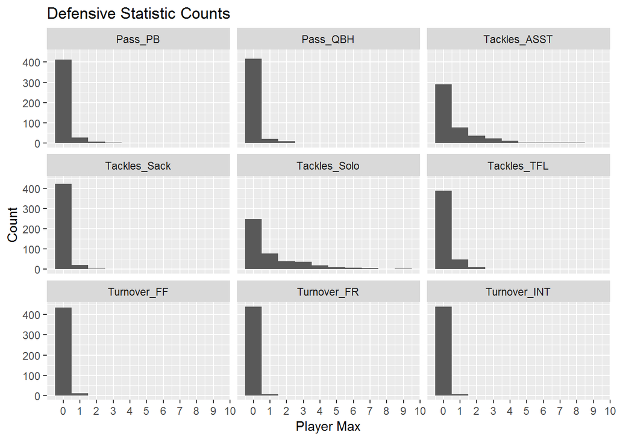

```r
ggplot(defCleanTid, aes(x = Count)) + geom_histogram(binwidth = 1) + facet_wrap(~Statistic) + scale_x_continuous(breaks = seq(0, 10, 1)) + labs(title = "Defensive Statistic Counts", x = "Player Max", y = "Count")
```

# Question 3: Did ISU have better defense against West Virginia or Kansas State? Answer this question by creating a scatterplot with x-axis being the number of solo tackles (by each player) against West Virginia, and y-axis being that against Kansas State. A large number of solo tackles indicates good defense.

```r
WVKS <- defClean %>% filter(Opponent_Opponent == "West Virginia" | Opponent_Opponent == "Kansas State") %>% select(Name, Opponent_Opponent, Tackles_Solo) %>% spread(Opponent_Opponent, Tackles_Solo) %>% mutate_all(funs(replace(., is.na(.), 0)))
print(tbl_df(WVKS), n = 500)
```

```
## # A tibble: 37 x 3
##    Name               `Kansas State` `West Virginia`
##    <fct>                       <dbl>           <dbl>
##  1 Akers, Landen                   1               0
##  2 Azunna, Arnold                  0               0
##  3 Bailey, Cordarrius              0               0
##  4 Bailey, JaQuan                  0               2
##  5 Benton, Spencer                 0               1
##  6 Butler, Hakeem                  0               1
##  7 Eisworth, Greg                  3               5
##  8 Francis, Chris                  0               0
##  9 Grant, Jatairis                 1               0
## 10 Greene, Conner                  0               0
## 11 Harvey, Willie                  7               1
## 12 Hummel, Jake                    3               2
```

[output cut: 25 more lines]

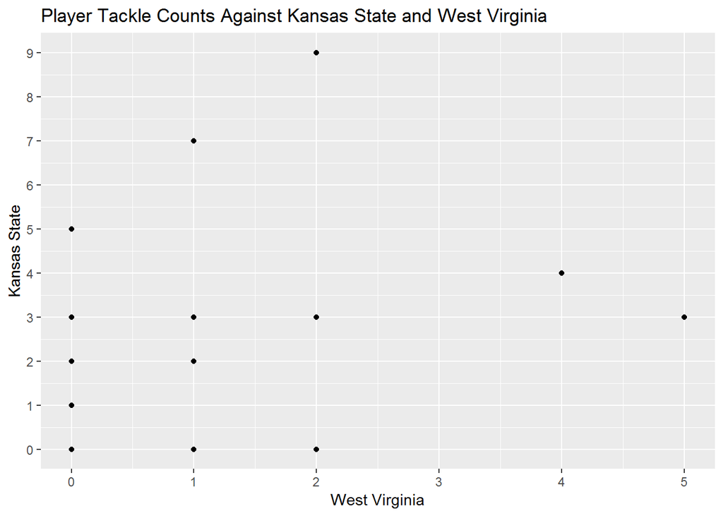

```r
ggplot(WVKS, aes(x = `West Virginia`, y = `Kansas State`)) + geom_point() + scale_y_continuous(breaks = seq(0,9,1)) + labs(title = "Player Tackle Counts Against Kansas State and West Virginia", x = "West Virginia", y = "Kansas State")
```

# Part Two: Tidying data(2)

```r
bioSeper <- bioClean %>% separate(Hometown, c("Town", "State"), sep = ",") %>% group_by(State) %>% summarize(n())

#the number of players from each state.
print(bioSeper)
```

```
## # A tibble: 25 x 2
##    State        `n()`
##    <chr>        <int>
##  1 " Ariz."         3
##  2 " Ark."          2
##  3 " Australia"     2
##  4 " Calif."        8
##  5 " D.C."          1
##  6 " Fla."          8
##  7 " Ga."           2
##  8 " Ill."          5
##  9 " Iowa"         44
## 10 " Kan."          3
## # ... with 15 more rows
```

# Part Three: Joining data frames

# Question 1: Find where do the offensive players come from by joining the offensive data and player biography data appropriately.

```r
offBio <- inner_join(offClean, bioClean, by = "Name")
print(tbl_df(offBio), n = 5)
```

```
## # A tibble: 163 x 19
##   Name  Opponent_Oppone~ Receiving_REC Receiving_YDS Receiving_TD
##   <chr> <fct>                    <dbl>         <dbl>        <dbl>
## 1 Jone~ Iowa                         1            31            0
## 2 Jone~ Oklahoma                     9            66            0
## 3 Jone~ Akron                        6            39            0
## 4 Jone~ TCU                          3            23            0
## 5 Jone~ Oklahoma State               6            37            1
## # ... with 158 more rows, and 14 more variables: Rushing_ATT <dbl>,
## #   Rushing_YDS <dbl>, Rushing_TD <dbl>, `Passing_CMP-ATT` <dbl>,
## #   Passing_YDS <dbl>, Passing_TD <dbl>, Passing_INT <dbl>,
## #   Position <chr>, Height <dbl>, Weight <dbl>, Class <chr>,
## #   Hometown <chr>, Highschool <chr>, na.rm <lgl>
```

# Question 2: Is there a relationship between the weight of a player and the receiving yards (Receiving_YDS)?

From what I can tell, it seems like there is a relationship between weight and receiving yards, but for some reason the receiving yards for the weight of 225 goes up immensely. If we were to exclude the weight of 225 then the plot appears to show a somewhat negative relationship.

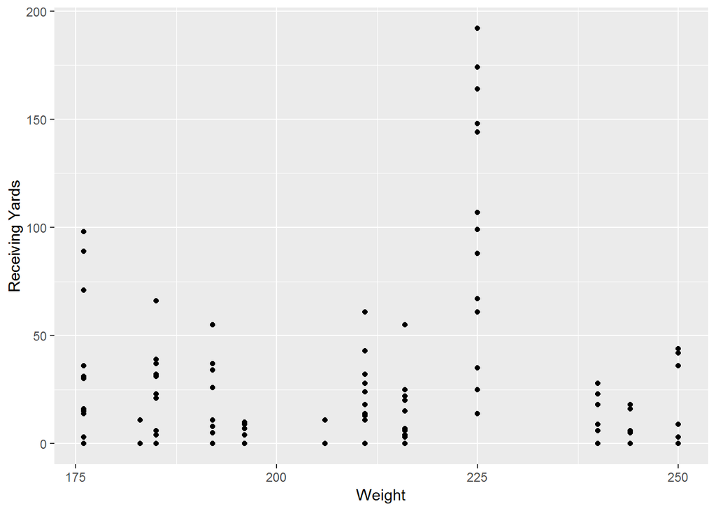

```r
ggplot(offBio, aes(x = Weight, y = Receiving_YDS)) + geom_point() + labs(Title = "Receiving Yards by Weight", x = "Weight", y = "Receiving Yards")
```

# Question 3: Explore more. Raise a question that can be answered only by looking at two or more data frames. Then answer that question.

```r
BioDef <- inner_join(defClean, bioClean, by = "Name")
```

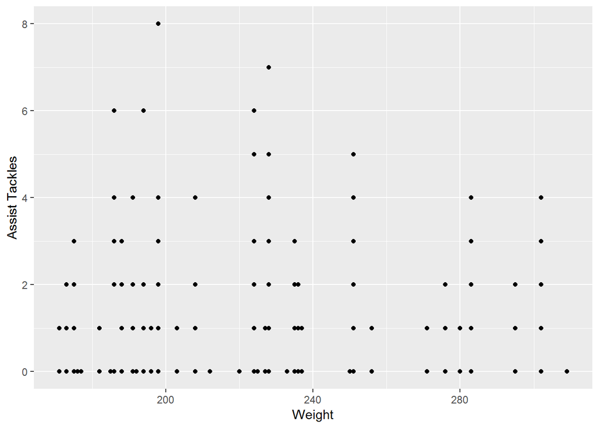

```r
ggplot(BioDef, aes(x = Weight, y = Tackles_ASST)) + geom_point() + labs(Title = "Assist Tackles by Weight", x = "Weight", y = "Assist Tackles")
```